# Ideal Solar Farm Locations in the Philippines

# Introduction

The Philippines is facing a significant energy crisis, partly due to the impending depletion of the Malampaya natural gas fields, which supply about 30% of Luzon's energy needs, expected to run dry by 2024-2025. This situation is exacerbated by an increasing population, high electricity costs—one of the highest in Southeast Asia—and the lingering effects of the COVID-19 pandemic on the energy sector. The government aims to boost the renewable energy share to 35% by 2030 and 50% by 2050 while acknowledging that an additional 52 GW of power capacity is needed by 2045, with the country currently lagging in developing necessary solutions.

In 2023, the Philippines faced a challenging energy landscape, with Energy Secretary Raphael Lotilla highlighting the potential for tight supply, particularly during the summer months, with risks of yellow and red alerts indicating thin reserves and insufficient supply to meet demand, respectively. The reliance on fossil fuels further complicates the situation, prompting a shift towards renewable energy sources to ensure more stable and affordable energy supplies.

The renewable energy sector, especially solar energy, presents a beacon of hope amidst these challenges. The Philippines' geographical location and climatic conditions offer substantial solar energy potential, with projections indicating a significant increase in solar capacity in the coming years. Solar microgrids, in particular, are identified as a viable solution to enhance energy distribution and accessibility, especially in the archipelago's more remote and island regions.

# Where is the best location to put up a solar farm in the Philippines?

# Selection Criteria

#### 1. **Slope** - Remove areas with high slope (>4° or 6.9927%)

- Source: [8]

#### 2. **Elevation** - Remove areas with high elevation (max elev. = 750m)

- Source: [8]

#### 3. **Powerline** - Areas must be near any powerline (within 1609.34m)

- Source: [1]

#### 4. **Road Proximity** - Areas must be near any major road (within 500m)

- Source: [10]

#### 5. **Protected Areas** - Remove protected areas (within 10km)

- Source: [2]

#### 6. **Land Cover** - Areas must be covered by grassland or open/barren

- Source: [9]

#### 7. **Power and Area** - Rank areas by total energy potential

- Source: [11]

```python
from PIL import Image
import rasterio
from rasterio.plot import show
from rasterio.features import shapes
import geopandas as gpd
from shapely.geometry import shape
import pandas as pd
import ee
import geemap
import matplotlib.pyplot as plt
import psycopg2
import numpy as np
import os
import fiona
from shapely import wkt
import warnings

warnings.filterwarnings("ignore")
```

# Module Installation and Initialization

```python
try:
    import geemap, ee
except ModuleNotFoundError:
    if 'google.colab' in str(get_ipython()):
        print("package not found, installing w/ pip in Google Colab...") ## for google collab
        !pip install geemap
    else:
        print("package not found, installing w/ conda...")
        !conda install mamba -c conda-forge -y   ## for your local directory
        !mamba install geemap -c conda-forge -y
    import geemap, ee
```

```python
try:
        ee.Initialize()    ## This is done anytime you want to use the google earth engine API.
except Exception as e:
        ee.Authenticate()  ## To help google earth engine link your account
        ee.Initialize()
```

```python
conn = psycopg2.connect(dbname="postgis",
                 user="gsa2022",
                 password="g5!V%T1Vmd",
                 host="192.168.212.99",
                 port=32771)
```

# 1. Global Administrative Areas (GADM)

Uploaded the brgy_shp from GADM file to complement with the data available in Earth Engine

```python
# Load the FeatureCollection
my_feature_collection = ee.FeatureCollection('projects/ee-rexgregorlaylo/assets/brgy_shp')
df_brgy = gpd.read_postgis('''SELECT * FROM gadm.ph_brgy''', conn)
```

# 2. Potential Voltage Electricity Data

Access the solar potential raster image in EE and convert it to GeoDataFrame

```python
pv_gdf = pd.DataFrame()
for prov_city in df_brgy.name_1.unique():
    location = my_feature_collection.filter(ee.Filter.eq('name_0', 'Philippines')).filter(ee.Filter.eq('name_1', prov_city))
    pvpotential = ee.Image("projects/ee-rexgregorlaylo/assets/PVOUT")

    # Add reducer output to the Features in the collection.
    pvpotential = pvpotential.reduceRegions(
        collection = location,
        reducer = ee.Reducer.mean(),
    );
    pv_data_info = pvpotential.getInfo()

    # Extract features from the data
    features = pv_data_info['features']

    # Create a list of dictionaries for each feature
    # Each dictionary will contain the properties and the geometry of the feature
    pv_data_list = []
    for feature in features:
        properties = feature['properties']
        geometry = shape(feature['geometry'])
        pv_data_list.append({**properties, 'geometry': geometry})

    # Convert the list of dictionaries to a GeoDataFrame
    pv_gdf_brgy = gpd.GeoDataFrame(pv_data_list, crs='EPSG:4326')
    pv_gdf_brgy.rename(columns={'mean':'mean_pv'}, inplace=True)
    pv_gdf = pd.concat([pv_gdf, pv_gdf_brgy], axis=0)
```

```python
pv_gdf[['name_3', 'name_2', 'name_1', 'name_0', 'mean_pv', 'geometry']].head()
```

|  | name_3 | name_2 | name_1 | name_0 | mean_pv | geometry |
| --- | --- | --- | --- | --- | --- | --- |
| 0 | Balais | Lagangilang | Abra | Philippines | 4.483699 | POLYGON ((120.73197 17.62722, 120.73286 17.617... |
| 1 | Cayapa | Lagangilang | Abra | Philippines | 4.429898 | POLYGON ((120.76954 17.64274, 120.77034 17.642... |
| 2 | Dalaguisen | Lagangilang | Abra | Philippines | 4.466777 | POLYGON ((120.73079 17.57696, 120.74548 17.576... |
| 3 | Laang | Lagangilang | Abra | Philippines | 4.486354 | POLYGON ((120.71674 17.60246, 120.72762 17.605... |
| 4 | Aguet | Lagangilang | Abra | Philippines | 4.493546 | POLYGON ((120.73352 17.61136, 120.73315 17.611... |

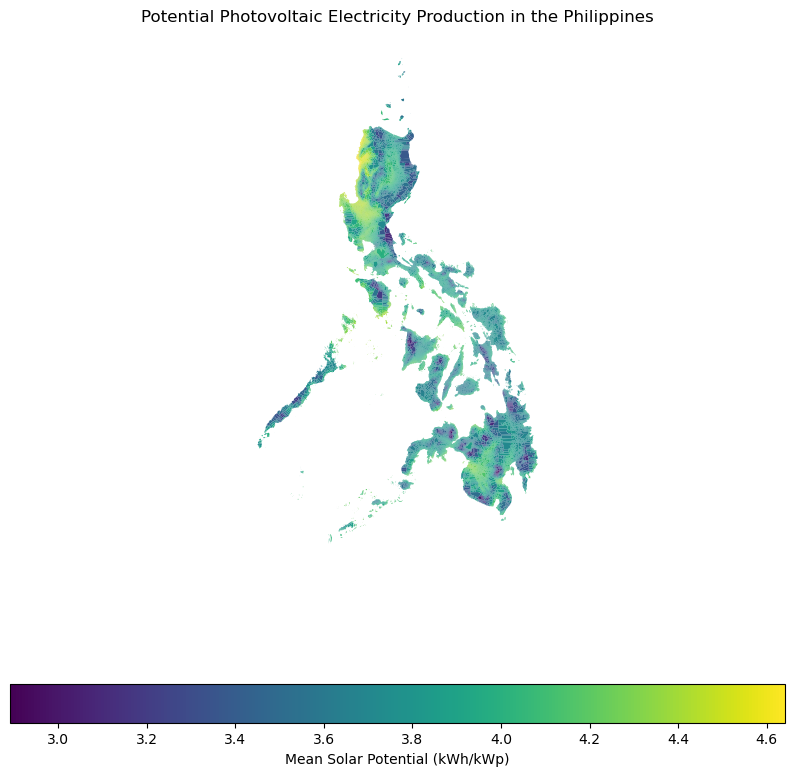

```python
fig, ax = plt.subplots(1, 1, figsize=(10, 10))
pv_gdf.plot(column='mean_pv', cmap='viridis', legend=True, ax=ax,
         legend_kwds={'label': "Mean Solar Potential (kWh/kWp)",
                      'orientation': "horizontal"})

ax.set_title('Potential Photovoltaic Electricity Production in the Philippines')
ax.set_axis_off()
plt.show()
```

# 3. Slope Dataset

The slope and elevation dataset is gathered data from `NASA/NASADEM_HGT/001` in Earth Engine.

```python
slope_gdf = pd.DataFrame()
for prov_city in df_brgy.name_1.unique():
    # Define the region of interest (ROI) as the Philippines.
    roi = my_feature_collection.filter(ee.Filter.eq('name_0', 'Philippines')).filter(ee.Filter.eq('name_1', prov_city))

    # A digital elevation model.
    dem = ee.Image('NASA/NASADEM_HGT/001').select('elevation').clip(roi)

    # Calculate slope.
    slope = ee.Terrain.slope(dem)

    # Convert slope to a feature collection.
    slope_fc = slope.reduceRegions(collection=roi, reducer=ee.Reducer.mean(), scale=30)

    # Convert the feature collection to a list.
    slope_list = slope_fc.getInfo()['features']

    data_list = []

    for feature in slope_list:
        geometry = shape(feature['geometry'])
        properties = feature['properties']
        data_list.append({**properties, 'geometry':geometry})

    # Create a GeoDataFrame
    slope_gdf_brgy = gpd.GeoDataFrame(data_list, crs='EPSG:4326')
    slope_gdf_brgy.rename(columns={'mean':'mean_slope'}, inplace=True)
    slope_gdf = pd.concat([slope_gdf, slope_gdf_brgy], axis=0)
```

```python
slope_gdf[['name_3', 'name_2', 'name_1', 'name_0', 'mean_slope', 'geometry']].head()
```

|  | name_3 | name_2 | name_1 | name_0 | mean_slope | geometry |
| --- | --- | --- | --- | --- | --- | --- |
| 0 | Balais | Lagangilang | Abra | Philippines | 6.048145 | POLYGON ((120.73197 17.62722, 120.73286 17.617... |
| 1 | Cayapa | Lagangilang | Abra | Philippines | 12.767927 | POLYGON ((120.76954 17.64274, 120.77034 17.642... |
| 2 | Dalaguisen | Lagangilang | Abra | Philippines | 3.227097 | POLYGON ((120.73079 17.57696, 120.74548 17.576... |
| 3 | Laang | Lagangilang | Abra | Philippines | 3.649284 | POLYGON ((120.71674 17.60246, 120.72762 17.605... |
| 4 | Aguet | Lagangilang | Abra | Philippines | 3.003336 | POLYGON ((120.73352 17.61136, 120.73315 17.611... |

```python
Map = geemap.Map()
dataset = ee.Image('NASA/NASADEM_HGT/001')
elevation = dataset.select('elevation')
elevationVis = {
    'min': 0,
    'max': 2000,
}
Map.addLayer(elevation.updateMask(elevation.gt(0)), elevationVis, 'Elevation')
Map.setCenter(121.7740, 12.8797, 6)
Map
```

```
Map(center=[12.8797, 121.774], controls=(WidgetControl(options=['position', 'transparent_bg'], widget=SearchDa…
```

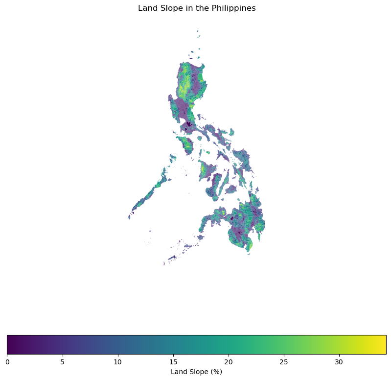

```python
fig, ax = plt.subplots(1, 1, figsize=(10, 10))
slope_gdf.plot(column='mean_slope', cmap='viridis', legend=True, ax=ax,
         legend_kwds={'label': "Land Slope (%)",
                      'orientation': "horizontal"})
ax.set_title('Land Slope in the Philippines')
ax.set_axis_off()
plt.show()
```

# 4. Elevation

The slope and elevation dataset is gathered data from `NASA/NASADEM_HGT/001` in Earth Engine.

```python
elev_gdf = pd.DataFrame()
for prov_city in df_brgy.name_1.unique():

    # Define the region of interest (ROI) as the Philippines.
    roi = my_feature_collection.filter(ee.Filter.eq('name_0', 'Philippines')).filter(ee.Filter.eq('name_1', prov_city))

    # A digital elevation model.
    terrain = ee.Image("NASA/NASADEM_HGT/001")

    # Add reducer output to the Features in the collection.
    terrain = terrain.reduceRegions(
        collection = roi,
        reducer = ee.Reducer.mean(),
    );

    ter_data_info = terrain.getInfo()

    # Extract features from the data
    features = ter_data_info['features']

    # Create a list of dictionaries for each feature
    # Each dictionary will contain the properties and the geometry of the feature
    data_list = []
    for feature in features:
        properties = feature['properties']
        geometry = shape(feature['geometry'])
        data_list.append({**properties, 'geometry': geometry})

    # Convert the list of dictionaries to a GeoDataFrame
    elev_gdf_brgy = gpd.GeoDataFrame(data_list)

    # Ensure the GeoDataFrame has the correct CRS
    elev_gdf_brgy.set_crs(epsg=4326, inplace=True)
    elev_gdf = pd.concat([elev_gdf, elev_gdf_brgy], axis=0)
```

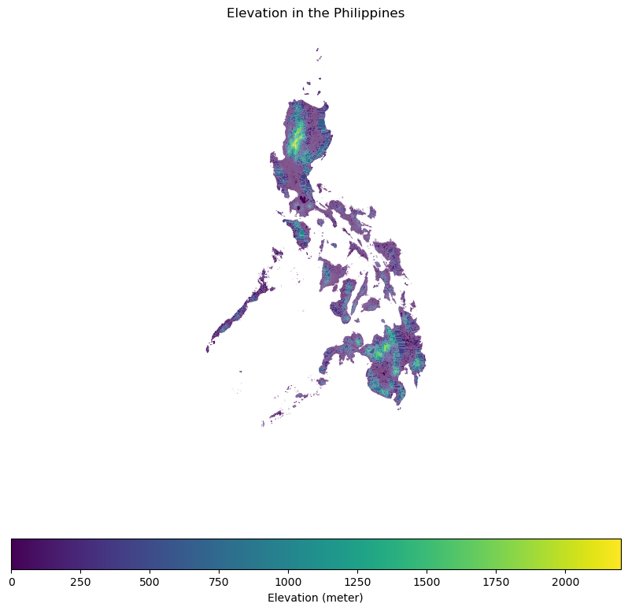

```python
# Plot the GeoDataFrame with 'mean' values determining the color
fig, ax = plt.subplots(1, 1, figsize=(10, 10))
elev_gdf.plot(column='elevation', cmap='viridis', legend=True, ax=ax,
         legend_kwds={'label': "Elevation (meter)",
                      'orientation': "horizontal"})

ax.set_title('Elevation in the Philippines')
ax.set_axis_off()
plt.show()
```

# 5. Road Proximity

OSM PH database is used to capture distance from major roads.

```python
df_road = gpd.read_postgis('''SELECT * FROM public.ph_roads''',
                           con=conn, geom_col='way')
df_road.head()
```

|  | osm_id | access | addr:housename | addr:housenumber | addr:interpolation | admin_level | aerialway | aeroway | amenity | area | ... | tracktype | tunnel | water | waterway | wetland | width | wood | z_order | way_area | way |
| --- | --- | --- | --- | --- | --- | --- | --- | --- | --- | --- | --- | --- | --- | --- | --- | --- | --- | --- | --- | --- | --- |
| 0 | -49915 | None | None | None | None | 2 | None | None | None | None | ... | None | None | None | None | None | None | None | 0 | None | LINESTRING (112.25590 8.89107, 112.26100 8.889... |
| 1 | -3622396 | None | None | None | None | 8 | None | None | None | None | ... | None | None | None | None | None | None | None | 0 | None | LINESTRING (112.25590 8.89107, 112.26100 8.889... |
| 2 | -1887959 | None | None | None | None | 4 | None | None | None | None | ... | None | None | None | None | None | None | None | 0 | None | LINESTRING (112.25590 8.89107, 112.26100 8.889... |
| 3 | -3479413 | None | None | None | None | 6 | None | None | None | None | ... | None | None | None | None | None | None | None | 0 | None | LINESTRING (112.25590 8.89107, 112.26100 8.889... |
| 4 | -1822309 | None | None | None | None | 6 | None | None | None | None | ... | None | None | None | None | None | None | None | 0 | None | LINESTRING (112.20465 8.87938, 112.19109 8.871... |

5 rows × 69 columns

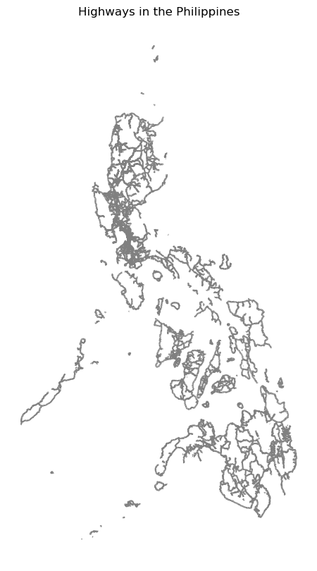

```python
df_highway = df_road[(df_road['highway']).notna()]
fig, ax = plt.subplots(1, 1, figsize=(10, 10))
df_highway.plot(ax=ax, color='gray')
ax.set_title('Highways in the Philippines')
ax.set_axis_off()
plt.show()
```

# 6. Protected Areas

```python
a = !pwd
# Get the first item from the list to get the current directory as a string
current_directory = a[0]
path = os.path.join(current_directory, 'protected_areas')
fiona.supported_drivers['KML'] = 'rw'

# Ensure that Fiona supports KML
fiona.supported_drivers['KML'] = 'rw'

# Assuming 'path' is defined and points to the directory containing your KML files
p_legal = gpd.read_file(f'{path}/protected_legislated.kml', driver='KML')
p_sea = gpd.read_file(f'{path}/protected_seascape.kml', driver='KML')
p_terra = gpd.read_file(f'{path}/protected_terrestrial.kml', driver='KML')

# Add a column indicating the source variable for each GeoDataFrame
p_legal['type'] = 'legal'
p_sea['type'] = 'sea'
p_terra['type'] = 'terra'

# Concatenate the GeoDataFrames
protected_df = pd.concat([p_legal, p_sea, p_terra], ignore_index=True)

# If you want to convert it back to a GeoDataFrame
protected_df = gpd.GeoDataFrame(protected_df, crs=p_legal.crs)
```

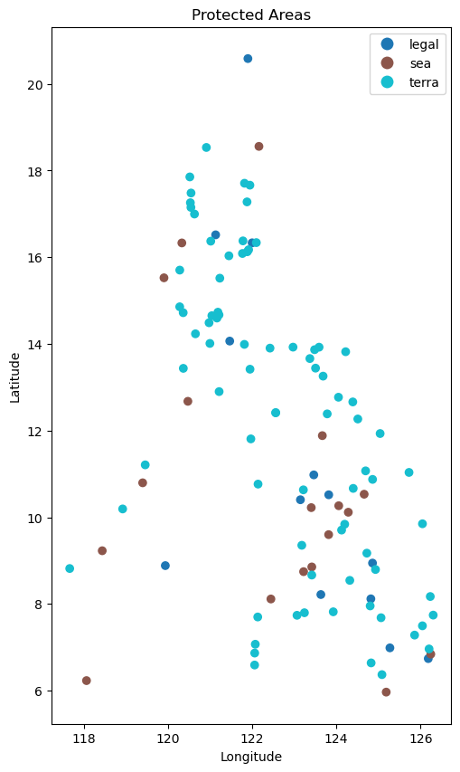

```python
fig, ax = plt.subplots(figsize=(10, 10))
protected_df.plot(ax=ax, column='type', legend=True, categorical=True, legend_kwds={'bbox_to_anchor': (1, 1)})
plt.title('Protected Areas')
plt.xlabel('Longitude')
plt.ylabel('Latitude')
plt.show()
```

# 7. Land Cover

```python
df_landcover = gpd.read_file('./filtered_landcover/filtered_landcover.shp')
```

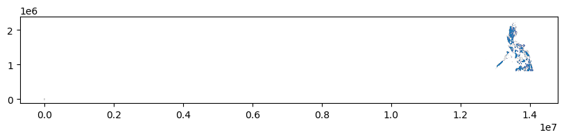

```python
ax = df_brgy.plot(figsize=(10, 10), zorder=5, color='lightgray', edgecolor='lightgray')
df_landcover.plot(ax=ax, zorder=15)
plt.savefig('df_landcover.png', dpi=300, transparent=True)
plt.show()
```

```python
province_to_region_map = {
    'Agusan del Norte': 'CAR',
    'Abra': 'CAR',
    'Apayao': 'CAR',
    'Kalinga': 'CAR',
    'Masbate': 'R5',
    'Aurora': 'R3',
    'Basilan': 'BARMM',
    'Catanduanes': 'R5',
    'Camiguin': 'R10',
    'Palawan': 'R4B',
    'Dinagat Islands': 'R13',
    'Sulu': 'BARMM',
    'Misamis Occidental': 'R10',
    'Siquijor': 'R7',
    'Quirino': 'R2',
    'Occidental Mindoro': 'R4B',
    'Zamboanga Sibugay': 'R9',
    'Romblon': 'R4B',
    'Tawi-Tawi': 'BARMM',
    'Cebu': 'R7',
    'Albay': 'R5',
    'Ifugao': 'CAR',
    'Batangas': 'R4A',
    'Bohol': 'R7',
    'Agusan del Sur': 'CAR',
    'Iloilo': 'R6',
    'Antique': 'R6',
    'Aklan': 'R6',
    'Leyte': 'R8',
    'Bataan': 'R3',
    'Cagayan': 'R2',
    'Ilocos Sur': 'R1',
    'Isabela': 'R2',
    'Bukidnon': 'R10',
    'Camarines Sur': 'R5',
    'Cavite': 'R4A',
    'Biliran': 'R8',
    'Lanao del Sur': 'BARMM',
    'Davao del Norte': 'R11',
    'Bulacan': 'R3',
    'Davao del Sur': 'R11',
    'Eastern Samar': 'R8',
    'Camarines Norte': 'R5',
    'Capiz': 'R6',
    'Nueva Vizcaya': 'R2',
    'Pangasinan': 'R1',
    'Compostela Valley': 'R11',
    'Samar': 'R8',
    'Davao Oriental': 'R11',
    'Guimaras': 'R6',
    'Ilocos Norte': 'R1',
    'South Cotabato': 'R12',
    'La Union': 'R1',
    'Surigao del Norte': 'R13',
    'Tarlac': 'R3',
    'Zambales': 'R3',
    'Zamboanga del Norte': 'R9',
    'Laguna': 'R4A',
    'Lanao del Norte': 'BARMM',
    'Maguindanao': 'BARMM',
    'Metropolitan Manila': 'NCR',
    'Marinduque': 'R4B',
    'Negros Oriental': 'R7',
    'Nueva Ecija': 'R3',
    'Misamis Oriental': 'R10',
    'Oriental Mindoro': 'R4B',
    'Negros Occidental': 'R6',
    'North Cotabato': 'R12',
    'Quezon': 'R4A',
    'Sorsogon': 'R5',
    'Rizal': 'R4A',
    'Northern Samar': 'R8',
    'Surigao del Sur': 'R13',
    'Zamboanga del Sur': 'R9',
    'Pampanga': 'R3',
    'Southern Leyte': 'R8',
    'Sarangani': 'R12',
    'Sultan Kudarat': 'R12'
}
```

# Data Analysis

### 1. Slope

Elimination of Barangay with high slope. High slope is greater than 4 degrees or 6.9927%.

### 2. ELevation

Elimination of Barangay beyond the maximum elevation of 750m.

```python
slope_gdf_ = slope_gdf[['gid_3', 'name_1', 'name_2',
                        'name_3', 'geometry', 'mean_slope']]

elev_gdf_ = elev_gdf[['geometry', 'elevation']]
slope_elev_gdf = pd.merge(slope_gdf_, elev_gdf_, how='left',
                          left_on='geometry', right_on='geometry')

slope_elev_pass = slope_elev_gdf.loc[
    (slope_elev_gdf['mean_slope'] < 6.9927) & (
        slope_elev_gdf['elevation'] < 750)]
slope_elev_pass.head()
```

|  | gid_3 | name_1 | name_2 | name_3 | geometry | mean_slope | elevation |
| --- | --- | --- | --- | --- | --- | --- | --- |
| 0 | PHL.1.10.3_1 | Abra | Lagangilang | Balais | POLYGON ((120.73197 17.62722, 120.73286 17.617... | 6.048145 | 75.336188 |
| 2 | PHL.1.10.5_1 | Abra | Lagangilang | Dalaguisen | POLYGON ((120.73079 17.57696, 120.74548 17.576... | 3.227097 | 75.820111 |
| 3 | PHL.1.10.6_1 | Abra | Lagangilang | Laang | POLYGON ((120.71674 17.60246, 120.72762 17.605... | 3.649284 | 67.001447 |
| 4 | PHL.1.10.1_1 | Abra | Lagangilang | Aguet | POLYGON ((120.73352 17.61136, 120.73315 17.611... | 3.003336 | 57.385533 |
| 6 | PHL.1.10.7_1 | Abra | Lagangilang | Lagben | POLYGON ((120.73197 17.62722, 120.72862 17.627... | 6.148235 | 69.256924 |

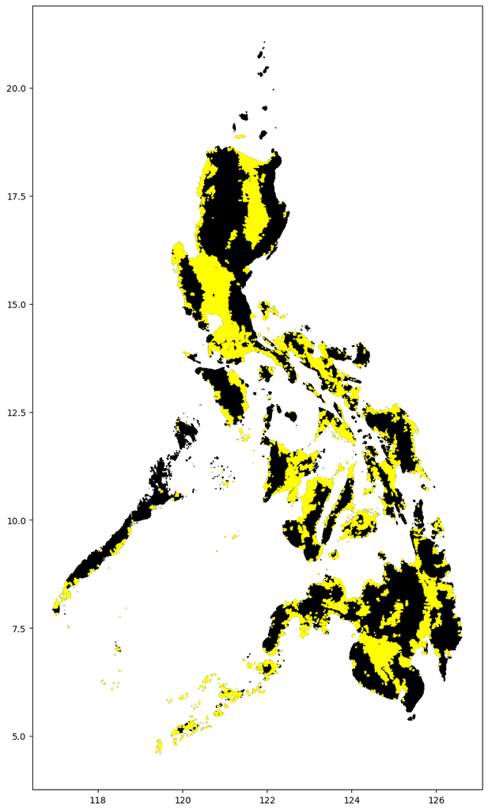

```python
ax = df_brgy.plot(figsize=(16, 16), color='k', zorder=5, edgecolor='k')
slope_elev_pass.plot(ax=ax, color='#FFFF00', zorder=15, edgecolor='#FFFF00')
plt.show()
```

### 3. Powerlines

Areas must be near any powerline (within 1609.34m or 1 mile)

```python
pass_power_gid3 = pd.read_csv('pass_power_gid3.csv').drop('Unnamed: 0', axis=1).squeeze()
slope_elev_power_pass = (slope_elev_pass[slope_elev_pass.gid_3.isin(pass_power_gid3)])
slope_elev_power_pass.head()
```

|  | gid_3 | name_1 | name_2 | name_3 | geometry | mean_slope | elevation |
| --- | --- | --- | --- | --- | --- | --- | --- |
| 436 | PHL.2.10.3_1 | Agusan del Norte | Nasipit | Ata-Atahon | POLYGON ((125.38520 8.95393, 125.38488 8.95499... | 5.191900 | 23.623590 |
| 438 | PHL.2.10.12_1 | Agusan del Norte | Nasipit | Cubi-Cubi | POLYGON ((125.38981 8.96821, 125.39289 8.98298... | 3.756228 | 11.318343 |
| 441 | PHL.2.10.15_1 | Agusan del Norte | Nasipit | Kinabjangan | POLYGON ((125.36311 8.98533, 125.36325 8.98636... | 5.492137 | 23.786708 |
| 442 | PHL.2.10.16_1 | Agusan del Norte | Nasipit | Punta | POLYGON ((125.34711 8.97694, 125.34941 8.97743... | 4.152775 | 19.108461 |
| 444 | PHL.2.10.18_1 | Agusan del Norte | Nasipit | Talisay | POLYGON ((125.33687 8.97979, 125.33599 8.97964... | 5.874018 | 17.217239 |

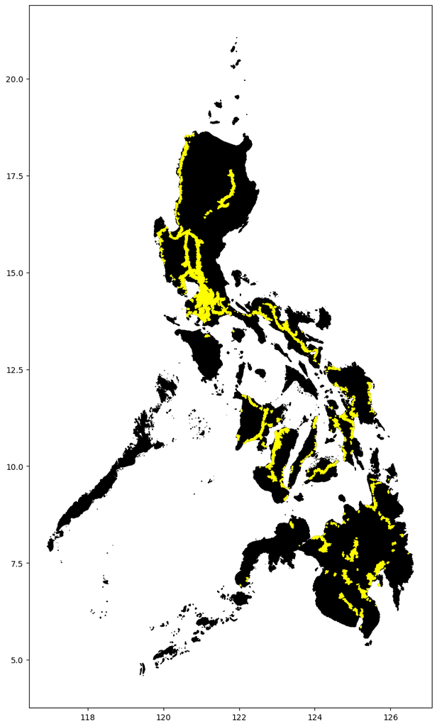

```python
ax = df_brgy.plot(figsize=(16, 16), color='k', zorder=5, edgecolor='k')
slope_elev_power_pass.plot(ax=ax, color='#FFFF00', zorder=15, edgecolor='#FFFF00')
plt.show()
```

### 4. Road Proximity

Areas must be near any major road (within 500m)

```python
road_pass = pd.read_csv('pass_road.csv')
road_pass.drop('Unnamed: 0', axis=1, inplace=True)
road_pass_gid3 = road_pass.squeeze()

slope_elev_power_road_pass = slope_elev_power_pass[slope_elev_power_pass.gid_3.isin(road_pass_gid3)]
slope_elev_power_road_pass.head()
```

|  | gid_3 | name_1 | name_2 | name_3 | geometry | mean_slope | elevation |
| --- | --- | --- | --- | --- | --- | --- | --- |
| 436 | PHL.2.10.3_1 | Agusan del Norte | Nasipit | Ata-Atahon | POLYGON ((125.38520 8.95393, 125.38488 8.95499... | 5.191900 | 23.623590 |
| 438 | PHL.2.10.12_1 | Agusan del Norte | Nasipit | Cubi-Cubi | POLYGON ((125.38981 8.96821, 125.39289 8.98298... | 3.756228 | 11.318343 |
| 441 | PHL.2.10.15_1 | Agusan del Norte | Nasipit | Kinabjangan | POLYGON ((125.36311 8.98533, 125.36325 8.98636... | 5.492137 | 23.786708 |
| 442 | PHL.2.10.16_1 | Agusan del Norte | Nasipit | Punta | POLYGON ((125.34711 8.97694, 125.34941 8.97743... | 4.152775 | 19.108461 |
| 444 | PHL.2.10.18_1 | Agusan del Norte | Nasipit | Talisay | POLYGON ((125.33687 8.97979, 125.33599 8.97964... | 5.874018 | 17.217239 |

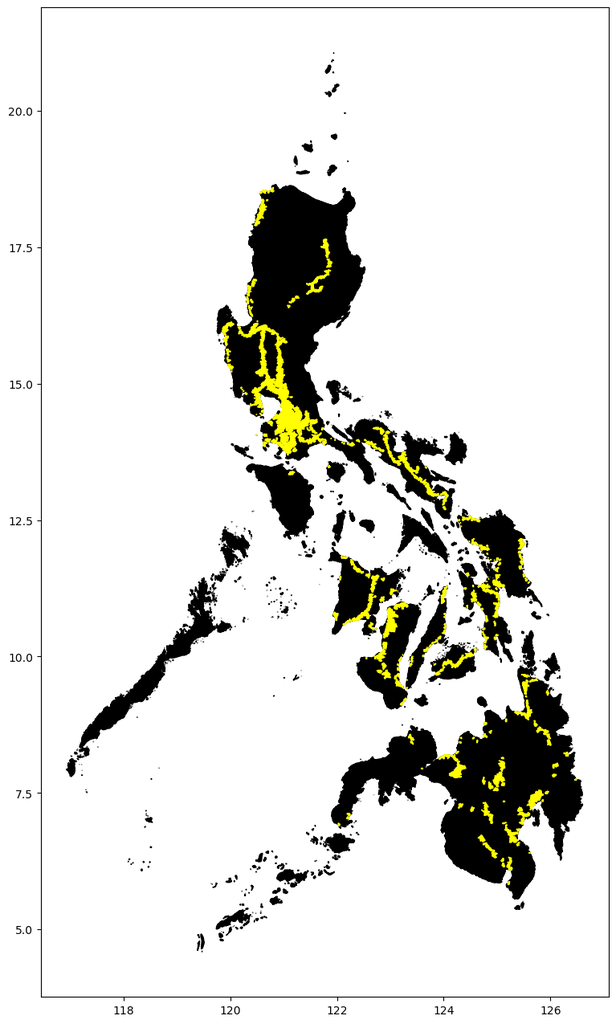

```python
ax = df_brgy.plot(figsize=(16, 16), color='k', zorder=5, edgecolor='k')
slope_elev_power_road_pass.plot(ax=ax, color='#FFFF00', zorder=15, edgecolor='#FFFF00')

plt.savefig('slope_elev_power_road_pass.png', dpi=300, transparent=True)
plt.show()
```

### 5. Protected Areas Pass

Remove locations within 10km-radius of any protected areas.

```python
pass_protect_gid3 = pd.read_csv('pass_protect_gid3.csv').drop('Unnamed: 0', axis=1).squeeze()
slope_elev_power_road_protected_pass = slope_elev_power_road_pass[slope_elev_power_road_pass.gid_3.isin(pass_protect_gid3)]
```

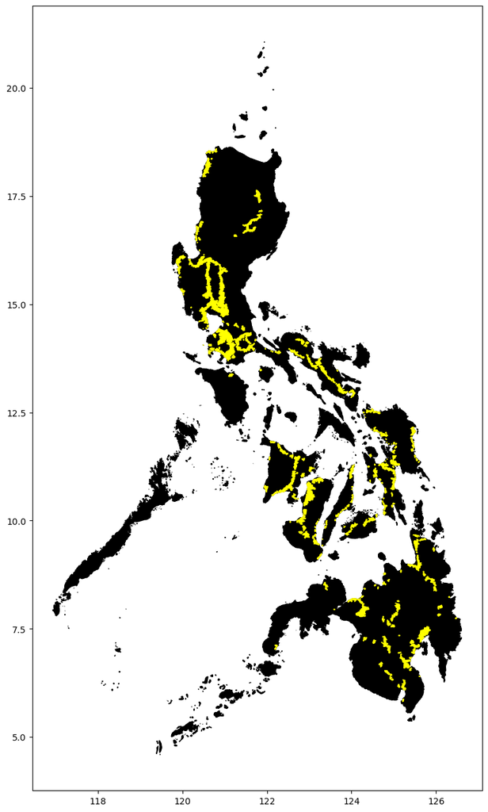

```python
ax = df_brgy.plot(figsize=(16, 16), color='k', zorder=5, edgecolor='k')
slope_elev_power_road_protected_pass.plot(ax=ax, color='#FFFF00', zorder=15, edgecolor='#FFFF00')

plt.savefig('slope_elev_power_road_protected_pass.png', dpi=300, transparent=True)
plt.show()
```

### 6. Land Cover Pass

Areas must be covered by grassland or open/barren

```python
slope_elev_power_road_protected_pass['equivalent_region'] = slope_elev_power_road_protected_pass['name_1'].apply(lambda x: province_to_region_map.get(x, ''))
df_landcover.to_crs(epsg=4326, inplace=True)
```

```python
regions = df_landcover['reg_code'].unique()

# Initialize an empty list to store joined dataframes
joined_data_list = []

# Iterate through each region
for region in regions:
    # Filter DataFrames for the current region
    filtered_df_landcover = df_landcover[df_landcover['reg_code'] == region]
    slope_elev_power_road_protected_landcover = slope_elev_power_road_protected_pass[slope_elev_power_road_protected_pass['equivalent_region'] == region]

    # Perform spatial join
    joined_data_region = gpd.sjoin(filtered_df_landcover, slope_elev_power_road_protected_landcover, op='intersects', how='inner')

    # Append the joined dataframe to the list
    joined_data_list.append(joined_data_region)

# Concatenate all the joined dataframes
slope_elev_power_road_protected_landcover_pass = pd.concat(joined_data_list)
```

```python
slope_elev_power_road_protected_landcover_pass.drop_duplicates(subset=['gid_3'], inplace=True)
slope_elev_power_road_protected_landcover_pass.head()
```

|  | class_id | class_name | province | reg_code | reg_name | area_ha | geometry | index_right | gid_3 | name_1 | name_2 | name_3 | mean_slope | elevation | equivalent_region |
| --- | --- | --- | --- | --- | --- | --- | --- | --- | --- | --- | --- | --- | --- | --- | --- |
| 739 | 14.0 | Grassland | Lanao Del Sur | BARMM | BANGSAMORO AUTONOMOUS REGION IN MUSLIM MINDANAO | 31.945505 | POLYGON ((124.15062 7.88160, 124.15058 7.88158... | 16945 | PHL.42.16.1_1 | Lanao del Sur | Lanao Lake | Lanao Lake | 1.069465 | 701.448443 | BARMM |
| 835 | 14.0 | Grassland | Lanao Del Sur | BARMM | BANGSAMORO AUTONOMOUS REGION IN MUSLIM MINDANAO | 7.262607 | POLYGON ((124.39213 7.94713, 124.39217 7.94712... | 17381 | PHL.42.29.17_1 | Lanao del Sur | Mulondo | Lama | 6.493123 | 747.658732 | BARMM |
| 839 | 14.0 | Grassland | Lanao Del Sur | BARMM | BANGSAMORO AUTONOMOUS REGION IN MUSLIM MINDANAO | 7.803265 | POLYGON ((124.37390 7.95777, 124.37398 7.95776... | 17884 | PHL.42.6.29_1 | Lanao del Sur | Buadiposo-Buntong | Raya Buntong | 3.238216 | 714.125315 | BARMM |
| 852 | 14.0 | Grassland | Lanao Del Sur | BARMM | BANGSAMORO AUTONOMOUS REGION IN MUSLIM MINDANAO | 67.967092 | POLYGON ((124.40354 7.99284, 124.40425 7.99278... | 17904 | PHL.42.6.23_1 | Lanao del Sur | Buadiposo-Buntong | Paling | 2.289524 | 710.968534 | BARMM |
| 854 | 14.0 | Grassland | Lanao Del Sur | BARMM | BANGSAMORO AUTONOMOUS REGION IN MUSLIM MINDANAO | 7.769416 | POLYGON ((124.34271 7.98945, 124.34281 7.98937... | 16865 | PHL.42.12.20_1 | Lanao del Sur | Ditsaan-Ramain | Lumbatan Ramain | 0.869930 | 697.244423 | BARMM |

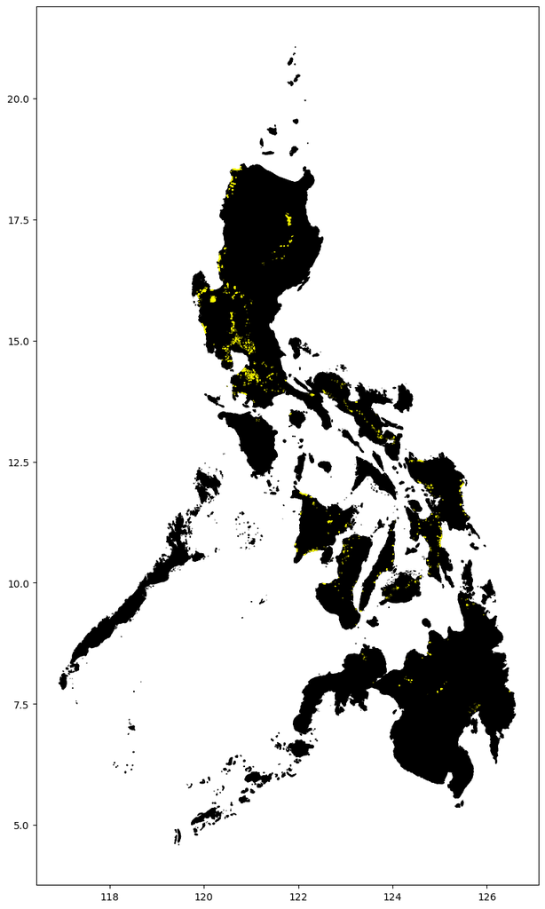

```python
ax = df_brgy.plot(figsize=(16, 16), color='k', zorder=5, edgecolor='k')
slope_elev_power_road_protected_landcover_pass.plot(ax=ax, color='#FFFF00', zorder=15, edgecolor='#FFFF00')

plt.show()
```

### 7. Power and Area

Rank areas by total energy potential (kWh)

```python
df_final = pd.merge(slope_elev_power_road_protected_landcover_pass , pv_gdf, on='gid_3')
df_final['area_ha x mean_pv'] = df_final['area_ha']*df_final['mean_pv']
df_final_bugallon = df_final[df_final['name_2_x'] == 'Bugallon']
# Set CRS
df_final.set_geometry('geometry_y', inplace=True)
df_final.crs = {'init': 'epsg:4326'}
df_final.head()
```

|  | class_id | class_name | province | reg_code | reg_name | area_ha | geometry_x | index_right | gid_3 | name_1_x | ... | name_1_y | name_2_y | name_3_y | nl_name_1 | nl_name_2 | nl_name_3 | type_3 | varname_3 | geometry_y | area_ha x mean_pv |
| --- | --- | --- | --- | --- | --- | --- | --- | --- | --- | --- | --- | --- | --- | --- | --- | --- | --- | --- | --- | --- | --- |
| 0 | 14.0 | Grassland | Lanao Del Sur | BARMM | BANGSAMORO AUTONOMOUS REGION IN MUSLIM MINDANAO | 31.945505 | POLYGON ((124.15062 7.88160, 124.15058 7.88158... | 16945 | PHL.42.16.1_1 | Lanao del Sur | ... | Lanao del Sur | Lanao Lake | Lanao Lake |  |  |  | Waterbody |  | POLYGON ((124.19592 7.79205, 124.19510 7.79161... | 123.212862 |
| 1 | 14.0 | Grassland | Lanao Del Sur | BARMM | BANGSAMORO AUTONOMOUS REGION IN MUSLIM MINDANAO | 7.262607 | POLYGON ((124.39213 7.94713, 124.39217 7.94712... | 17381 | PHL.42.29.17_1 | Lanao del Sur | ... | Lanao del Sur | Mulondo | Lama |  |  |  | Barangay | Bagoaingud | POLYGON ((124.36850 7.95018, 124.36850 7.94069... | 26.171245 |
| 2 | 14.0 | Grassland | Lanao Del Sur | BARMM | BANGSAMORO AUTONOMOUS REGION IN MUSLIM MINDANAO | 7.803265 | POLYGON ((124.37390 7.95777, 124.37398 7.95776... | 17884 | PHL.42.6.29_1 | Lanao del Sur | ... | Lanao del Sur | Buadiposo-Buntong | Raya Buntong |  |  |  | Barangay | Buntong East | POLYGON ((124.38935 7.97141, 124.38126 7.96560... | 28.305027 |
| 3 | 14.0 | Grassland | Lanao Del Sur | BARMM | BANGSAMORO AUTONOMOUS REGION IN MUSLIM MINDANAO | 67.967092 | POLYGON ((124.40354 7.99284, 124.40425 7.99278... | 17904 | PHL.42.6.23_1 | Lanao del Sur | ... | Lanao del Sur | Buadiposo-Buntong | Paling |  |  |  | Barangay |  | POLYGON ((124.39606 7.98358, 124.40144 7.98650... | 248.440134 |
| 4 | 14.0 | Grassland | Lanao Del Sur | BARMM | BANGSAMORO AUTONOMOUS REGION IN MUSLIM MINDANAO | 7.769416 | POLYGON ((124.34271 7.98945, 124.34281 7.98937... | 16865 | PHL.42.12.20_1 | Lanao del Sur | ... | Lanao del Sur | Ditsaan-Ramain | Lumbatan Ramain |  |  |  | Barangay |  | POLYGON ((124.34499 7.99585, 124.34433 7.99636... | 29.271969 |

5 rows × 34 columns

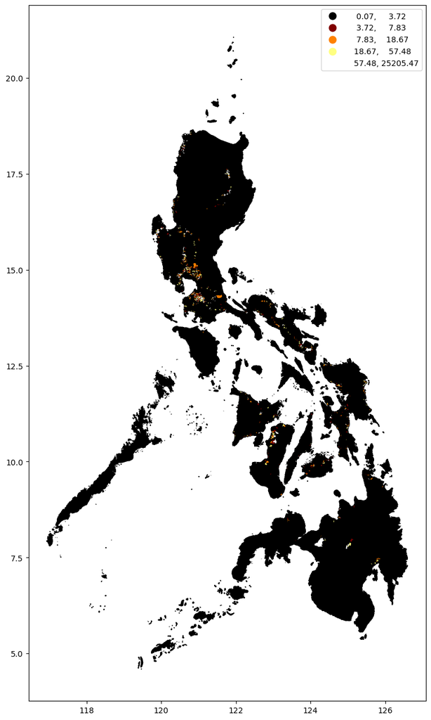

```python
ax = df_brgy.plot(figsize=(16, 16), color='k', zorder=5, edgecolor='k')
df_final.plot(column='area_ha x mean_pv', ax=ax, cmap='afmhot', scheme='quantiles', legend=True, zorder=15)
plt.show()
```

# Results and Discussion

1. `Land Area Determination`

The total land area of the municipality, as indicated by the dataset, was examined at the granularity of individual barangays that met the selection criteria.

2. `Photovoltaic Electricity Production Estimation`

This land area was then multiplied by the mean potential photovoltaic electricity production (PVOUT) expressed in kWh/kWp to estimate the electricity that could potentially be generated.

3. `Solar System Area Requirement`

It was assumed that a 1 kWp solar system necessitates approximately 10 square meters (or 100 square feet) of shadow-free area. This assumption was utilized to determine the total kWh potential. [6]

4. `Sunlight Availability`

The calculation took into account that sunlight is available for an average of 10 hours per day, thereby estimating the potential daily kWh production.

5. `Unit Conversion`

The land area measured in hectares was converted to square meters to maintain dimensional consistency throughout the calculations.

6. `Annual Operation Days`

The annual potential kWh was then calculated by considering 300 operational days per year, which allows for maintenance periods and other non-operational days.

7. `Solar Panel Efficiency`

An efficiency factor of 17% for the solar panels was incorporated to adjust the theoretical output to more realistic, expected values.

8. `Solar Energy Price`

### Formula:

```python
df_top3 = df_final.groupby(['name_2_x', 'name_1_x'])[['area_ha x mean_pv']].sum().sort_values(by='area_ha x mean_pv', ascending=False)
df_top3['kWh/year'] = df_top3['area_ha x mean_pv'] * 10000 * 0.1 * 10/24 * 300 * 0.17
df_top3['GWh/year'] = df_top3['area_ha x mean_pv'] * 10000 * 0.1 * 10/24 * 300 * 1/1_000_000 * 0.17
df_top3['Potential Earnings in Million Php/Year'] = df_top3['kWh/year'] * 9.68 * 1/1_000_000 * 1/10
df_top3.head(3)
```

| name_2_x | name_1_x | area_ha x mean_pv | kWh/year | GWh/year | Potential Earnings in Million Php/Year |
| --- | --- | --- | --- | --- | --- |
| Bugallon | Pangasinan | 25212.870581 | 5.357735e+08 | 535.773500 | 518.628748 |
| Aguilar | Pangasinan | 25158.527612 | 5.346187e+08 | 534.618712 | 517.510913 |
| Dumarao | Capiz | 6737.479707 | 1.431714e+08 | 143.171444 | 138.589958 |

```python
df_pangasinan = df_brgy[df_brgy.name_1 == 'Pangasinan']
df_capiz = df_brgy[df_brgy.name_1 == 'Capiz']
df_top_location = df_brgy[df_brgy.name_2 == 'Bugallon']
df_top_location_2 = df_brgy[df_brgy.name_2 == 'Aguilar']
df_top_location_3 = df_brgy[df_brgy.name_2 == 'Dumarao']
```

# Top 3 Solar Farm Locations

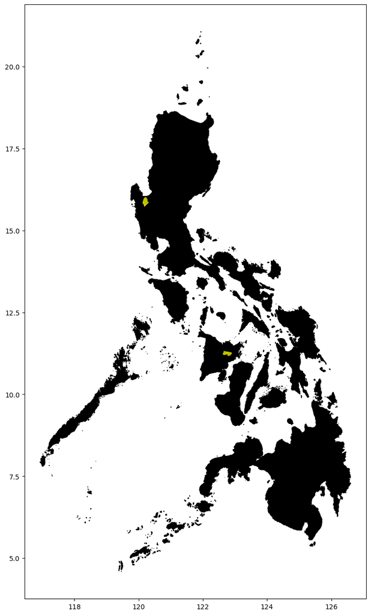

```python
ax = df_brgy.plot(figsize=(16, 16), color='k', zorder=5, edgecolor='k')
df_top_location.plot(ax=ax, color='#FFFF00', zorder=15, edgecolor='y')
df_top_location_2.plot(ax=ax, color='#FFFF00', zorder=15, edgecolor='y')
df_top_location_3.plot(ax=ax, color='#FFFF00', zorder=15, edgecolor='y')
plt.savefig('df_top_location.png', dpi=300, transparent=True)
plt.show()
```

# Top 1 : Bugallon, Pangasinan

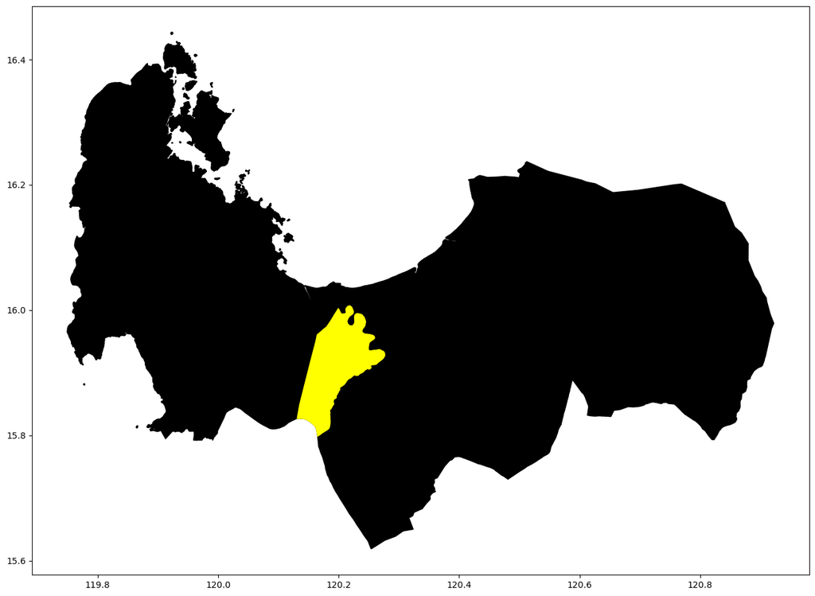

```python
ax = df_pangasinan.plot(figsize=(16, 16), color='k', zorder=5, edgecolor='k')
df_top_location.plot(ax=ax, color='#FFFF00', zorder=15, edgecolor='#FFFF00')

plt.savefig('df_top_location_municipality.png', dpi=300, transparent=True)
plt.show()
```

# Top 2: Aguilar, Pangasinan

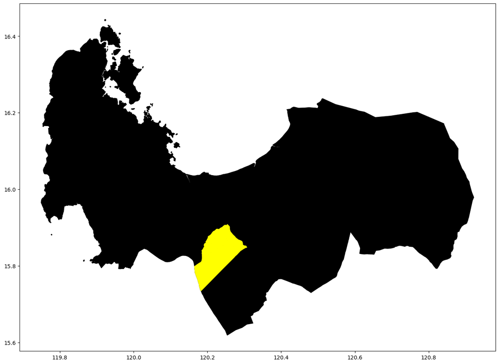

```python
ax = df_pangasinan.plot(figsize=(16, 16), color='k', zorder=5, edgecolor='k')
df_top_location_2.plot(ax=ax, color='#FFFF00', zorder=15, edgecolor='#FFFF00')

plt.savefig('df_top2_location_municipality.png', dpi=300, transparent=True)
plt.show()
```

# Top 3: Dumarao, Capiz

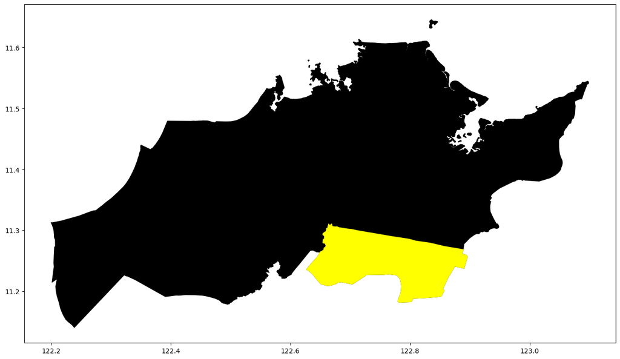

```python
ax = df_capiz.plot(figsize=(16, 16), color='k', zorder=5, edgecolor='k')
df_top_location_3.plot(ax=ax, color='#FFFF00', zorder=15, edgecolor='#FFFF00')

plt.savefig('df_top3_location_municipality.png', dpi=300, transparent=True)
plt.show()
```

1. **High Solar Potential**

   With potential earnings exceeding 500 million PHP annually for both Pangasinan locations, it's clear that solar energy could be a significant economic driver.
3. **Comparative Analysis**

   This results can be useful for local or national policymakers to prioritize investments in renewable energy, especially in areas with high solar potential.
5. **Investment Opportunities**

   For investors or companies in the renewable energy sector, this data highlights promising opportunities, particularly in Bugallon and Aguilar, due to their significant energy output and potential earnings.m

# References

1. Solar Farm Land Requirements & Solar Developments | YSG Solar. (n.d.). YSG Solar. https://www.ysgsolar.com/blog/solar-farm-land-requirements-solar-developments-ysg-solar
2. Alexandre, B., Crouzeilles, R., & Viveiros Grelle, C. E. (2010). How can we estimate buffer zones of protected areas? A proposal using biological data.
3. Odogwu, C. (2023, August 18). This is how much sunlight your solar panel system needs. CNET. https://www.cnet.com/home/energy-and-utilities/peak-sun-hours/#google_vignette
4. Comparable 500 hectare solar farm ACEN. (2024, February 8). SanMar Solar - ACEN. https://www.acenrenewables.com/project/sanmar-solar/
5. Philippines: approved FIT rates by source 2023 | Statista. (2023, June 9). Statista. https://www.statista.com/statistics/1381667/philippines-approved-fit-rates-by-source/#:~:text=As%20of%20March%2031%2C%202023,Philippine%20pesos%20per%20kilowatt%20hour.
6. 1 kWp solar system requires approximately 10 sq. m (or 100 sq. ft) of shadow free area. Source: Frequently asked questions- Solar Energy Solution | UNEeCOps Solar. (2022, January 20). Uneecops Solar. https://www.uneecopssolar.com/frequently-asked-questions/
7. Photovoltaic Energy Factsheet. (n.d.). Center for Sustainable Systems. https://css.umich.edu/publications/factsheets/energy/photovoltaic-energy-factsheet#:~:text=Though%20most%20commercial%20panels%20have,cells%20with%20efficiencies%20approaching%2050%25.
8. Mokarram, M., Mokarram, M. J., Khosravi, M. R., Saber, A., & Rahideh, A. (2020). Determination of the optimal location for constructing solar photovoltaic farms based on multi-criteria decision system and Dempster–Shafer theory. Scientific Reports, 10(1). https://doi.org/10.1038/s41598-020-65165-z
9. Figure 3. Solar power potential ranked by land cover classification (2019). ResearchGate. https://www.researchgate.net/figure/Solar-power-potential-ranked-by-land-cover-classification-The-centerlines-box-height_fig3_335021483
10. Galvan, J. P. D. (2021). Suitability Analysis for Solar Energy System Development using GIS and AHP in Cagayan Province, Philippines. Mindanao Journal of Science and Technology, 19(2), 107-125
11. Solar resource maps of Philippines. (2024). https://solargis.com/maps-and-gis-data/download/philippines